# RA1_template

## Before doing the assignment, load the library first

```r
library(dplyr)
```

```r
library(ggplot2)
```

## Load the data

```r
activity <- read.csv("activity.csv")
```

## Clean up data

```r
activity$date <- as.Date(activity$date, "%Y-%m-%d")
```

## Calculate the total number of steps taken per day

```r
by.day <- group_by(activity, date)
total <- summarize(by.day , total.steps = sum(steps,na.rm = TRUE))
total
```

```
## # A tibble: 61 × 2
##          date total.steps
##        <date>       <int>
## 1  2012-10-01           0
## 2  2012-10-02         126
## 3  2012-10-03       11352
## 4  2012-10-04       12116
## 5  2012-10-05       13294
## 6  2012-10-06       15420
## 7  2012-10-07       11015
## 8  2012-10-08           0
## 9  2012-10-09       12811
## 10 2012-10-10        9900
## # ... with 51 more rows
```

## Make a histogram of the total number of setps taken each day

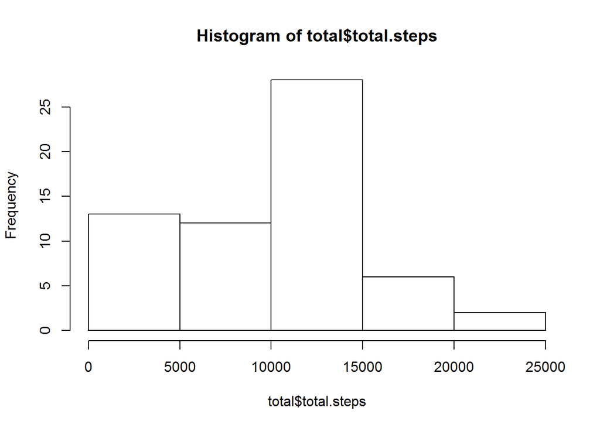

```r
hist(total$total.steps)
```

## Calculate and report the mean and median of the total number of steps taken per day

```r
mean.steps <- mean(total$total.steps)
median.steps <- median(total$total.steps)

## The mean is
mean.steps
```

```
## [1] 9354.23
```

```r
## The median is
median.steps
```

```
## [1] 10395
```

## Make a time series plot (i.e. type = “l”) of the 5-minute interval (x-axis) and the average number of steps taken, averaged across all days (y-axis)

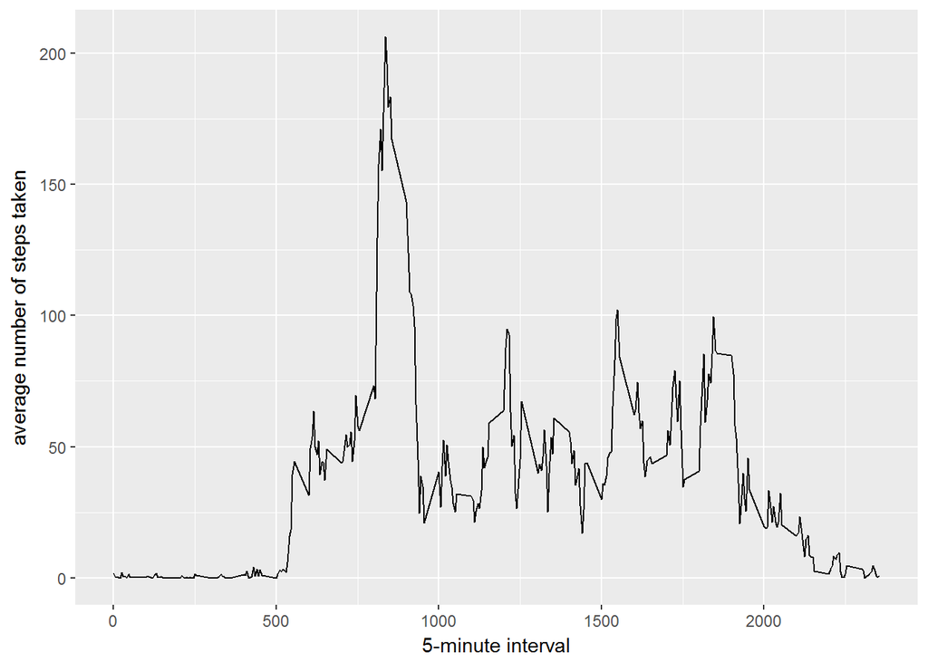

```r
averages <- aggregate(x=list(steps=activity$steps), by=list(interval=activity$interval),
                      FUN=mean, na.rm=TRUE)

ggplot(data=averages, aes(x=interval, y=steps)) +
    geom_line() +
    xlab("5-minute interval") +
    ylab("average number of steps taken")
```

## Which 5-minute interval, on average across all the days in the dataset, contains the maximum number of steps?

```r
averages[max(averages$steps),]
```

[output not shown]

## Calculate and report the total number of missing values in the dataset (i.e. the total number of rows with NAs)

```r
NAs <- is.na(activity$steps)
table(NAs)
```

```
## NAs
## FALSE  TRUE
## 15264  2304
```

## Devise a strategy for filling in all of the missing values in the dataset. The strategy does not need to be sophisticated. For example, you could use the mean/median for that day, or the mean for that 5-minute interval, etc.

```r
fill.value <- function(steps, interval) {
    filled <- NA
    if (!is.na(steps))
        filled <- c(steps)
    else
        filled <- (averages[averages$interval==interval, "steps"])
    return(filled)
}
```

## Create a new dataset that is equal to the original dataset but with the missing data filled in.

```r
filled.activity <- activity
filled.activity$steps <- mapply(fill.value, filled.activity$steps, filled.activity$interval)
```

## Make a histogram of the total number of steps taken each day and Calculate and report the mean and median total number of steps taken per day. Do these values differ from the estimates from the first part of the assignment? What is the impact of imputing missing data on the estimates of the total daily number of steps?

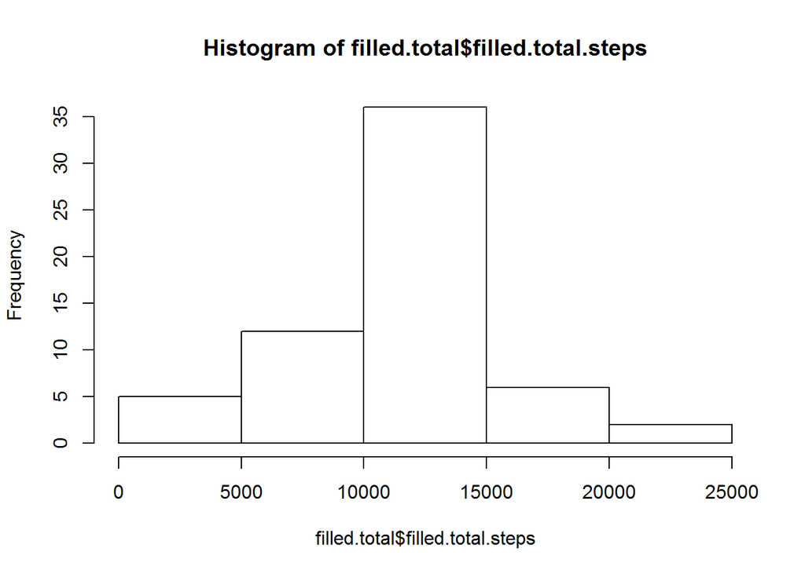

```r
filled.by.day <- group_by(filled.activity, date)
filled.total <- summarize(filled.by.day , filled.total.steps = sum(steps,na.rm = TRUE))
hist(filled.total$filled.total.steps)
```

```r
filled.mean.steps <- mean(filled.total$filled.total.steps)
filled.median.steps <- median(filled.total$filled.total.steps)

## The filled data mean is
filled.mean.steps
```

```
## [1] 10766.19
```

```r
## The filled data median is
filled.median.steps
```

```
## [1] 10766.19
```

The mean and median in the filled dataset are slightly higher than in the original dataset. The reason is that, be default, the NAs would be treated as 0 but the in filled dataset, the NAs are treated as mean, which increase the total steps number and as a result, increase mean and median.

## Create a new factor variable in the dataset with two levels - “weekday” and “weekend” indicating whether a given date is a weekday or weekend day.

```r
weekend <- function(date) {
    day <- weekdays(date)
    if (day %in% c("Monday", "Tuesday", "Wednesday", "Thursday", "Friday"))
        return("weekday")
    else if (day %in% c("Saturday", "Sunday"))
        return("weekend")
    else
        stop("invalid date")
}
filled.activity$date <- as.Date(filled.activity$date)
filled.activity$day <- sapply(filled.activity$date, FUN=weekend)
```

## Make a panel plot containing a time series plot (i.e. type = “l”) of the 5-minute interval (x-axis) and the average number of steps taken, averaged across all weekday days or weekend days (y-axis). See the README file in the GitHub repository to see an example of what this plot should look like using simulated data.

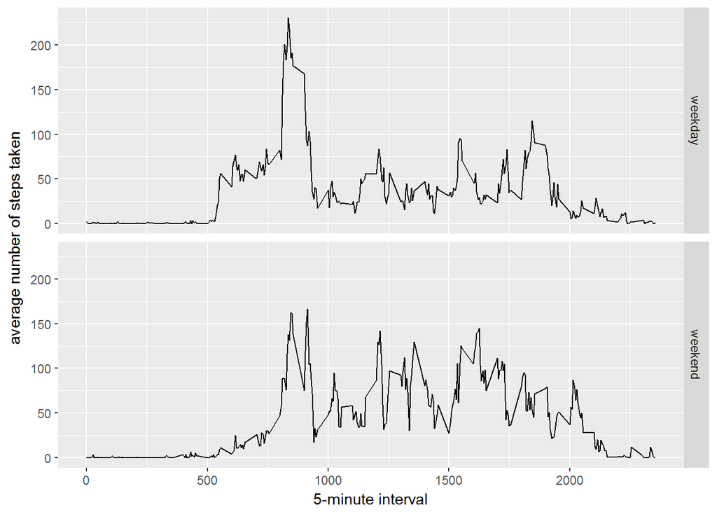

```r
filled.averages <- aggregate(steps ~ interval + day, data=filled.activity, mean)

ggplot(data=filled.averages, aes(x=interval, y=steps)) +
    geom_line() +
    facet_grid(day ~ .)+
    xlab("5-minute interval") +
    ylab("average number of steps taken")
```